# Sentiment analysis for UK 2019 general election candidates

In this task, you will get a sample of Tweets mentioning the two leading party candidates for the UK election (scheduled for December 12, 2019): Boris Johnson and Jeremy Corbyn.

## Getting the data

Use the **rtweet** package to get two samples of Tweets: - a set for Boris Johnson, and - a set for Jeremy Corbyn.

```r
library("rtweet")

JC <- "Jeremy Corbyn"
BJ <- "Boris Johnson"

jc_tweets <- search_tweets(
  JC, n = 1000, include_rts = FALSE
)

bj_tweets <- search_tweets(
  BJ, n = 1000, include_rts = FALSE
)

labour_tweets <- search_tweets(
  "Labour", n = 1000, include_rts = FALSE
)

conservative_tweets <- search_tweets(
  "Conservative", n = 1000, include_rts = FALSE
)

origin <- c(rep("Corbyn", 1000),
            rep("Boris", 1000),
            rep("Labour", 1000),
            rep("Conservative", 1000))

# Some names can be for other people
data = rbind(jc_tweets, bj_tweets, labour_tweets, conservative_tweets)
data$origin <- origin
```

You can refer to the (updated) example from Week 7’s REST example, using the `search_tweets()` function. Get as large a sample as you can, with equal numbers for both sides. Consider your search patterns carefully!

## Comparing sentiment

Use the **quanteda** package to analyze the sentiment for the tweets. This will involve:

- converting the tweet objects to a quanteda corpus (this works with `corpus()`)
- adding a new document variable called `candidate` to each corpus (there should be two), using the `docvars(corpus1, "candidate") <- "corbyn"` (for instance)
- adding the two corpora together, see `?`.corpus``.
- creating a dfm using the built-in `data_dictionary_LSD2015`. See `?dfm` and the `dictionary` argument. To group the documents, consider the `groups` argument for the new `candidate` document variable.

```r
library(quanteda)
corp_jc <- corpus(jc_tweets)

corp_bj <- corpus(bj_tweets)

# add doc variable
docvars(corp_jc, "candidate") <- "corbyn"
docvars(corp_bj, "candidate") <- "boris"

# Add them toguether
corpus_data <- corp_bj + corp_jc

# Create a DFM
dfm <- dfm(x = corpus_data,
           dictionary = data_dictionary_LSD2015,
           groups = "candidate")

dfm
```

```
## Document-feature matrix of: 2 documents, 4 features (0.0% sparse).
## 2 x 4 sparse Matrix of class "dfm"
##         features
## docs     negative positive neg_positive neg_negative
##   boris      1484     1213            6            5
##   corbyn     1180      907           14            4
```

```r
dfm_mat <- data.frame(matrix(dfm@x, nrow = 2, dimnames = dfm@Dimnames))
dfm_mat$candidate <- dfm@Dimnames[[1]]
dfm_mat
```

```
##        negative positive neg_positive neg_negative candidate
## boris      1484     1213            6            5     boris
## corbyn     1180      907           14            4    corbyn
```

# Interpret the results

Here you can compare the positive to negative words for each candidate, possibly using a plot.

```r
library(tidyverse)
```

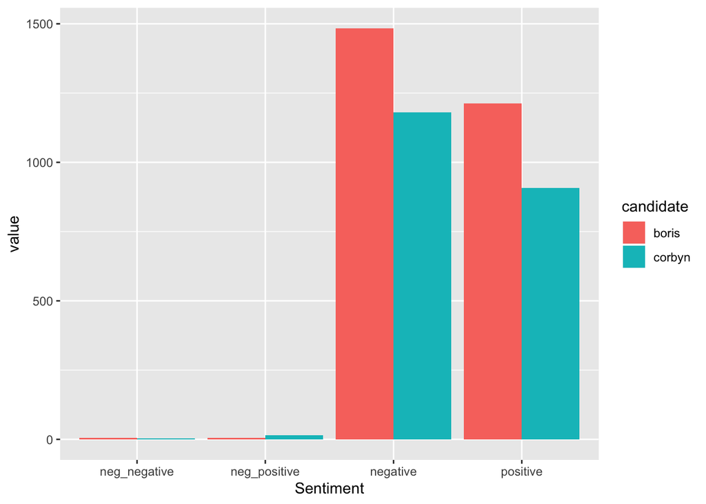

```r
dta_long <- pivot_longer(dfm_mat,cols = c("negative", "positive",
                              "neg_positive","neg_negative")
             , names_to = "Sentiment")

ggplot(data = dta_long, aes(x = Sentiment, y = value, fill = candidate)) +
  geom_bar(stat = 'identity', position = 'dodge')
```